# Week 5 Discussion - MDS

# Multidimensional Scaling (MDS)

# Task 1:

### The “nba.csv” contains 50 NBA players’ basketball statistics. Please use metric MDS scaling method to build a map that shows how the players are grouped, and then please discuss your observations and implications.

```r
nba <- read.csv("C:/Users/bae96639/Desktop/Uploads/nba.csv")
head(nba)
```

```
##             Name  G  MIN  PTS  FGM  FGA   FGP FTM FTA   FTP X3PM X3PA  X3PP ORB
## 1   Dwyane Wade  79 38.6 30.2 10.8 22.0 0.491 7.5 9.8 0.765  1.1  3.5 0.317 1.1
## 2  LeBron James  81 37.7 28.4  9.7 19.9 0.489 7.3 9.4 0.780  1.6  4.7 0.344 1.3
## 3   Kobe Bryant  82 36.2 26.8  9.8 20.9 0.467 5.9 6.9 0.856  1.4  4.1 0.351 1.1
## 4 Dirk Nowitzki  81 37.7 25.9  9.6 20.0 0.479 6.0 6.7 0.890  0.8  2.1 0.359 1.1
## 5 Danny Granger  67 36.2 25.8  8.5 19.1 0.447 6.0 6.9 0.878  2.7  6.7 0.404 0.7
## 6  Kevin Durant  74 39.0 25.3  8.9 18.8 0.476 6.1 7.1 0.863  1.3  3.1 0.422 1.0
##   DRB TRB AST STL BLK  TO  PF
## 1 3.9 5.0 7.5 2.2 1.3 3.4 2.3
## 2 6.3 7.6 7.2 1.7 1.1 3.0 1.7
## 3 4.1 5.2 4.9 1.5 0.5 2.6 2.3
## 4 7.3 8.4 2.4 0.8 0.8 1.9 2.2
## 5 4.4 5.1 2.7 1.0 1.4 2.5 3.1
## 6 5.5 6.5 2.8 1.3 0.7 3.0 1.8
```

```r
library(dplyr)
names(nba)
```

```
##  [1] "Name" "G"    "MIN"  "PTS"  "FGM"  "FGA"  "FGP"  "FTM"  "FTA"  "FTP"
## [11] "X3PM" "X3PA" "X3PP" "ORB"  "DRB"  "TRB"  "AST"  "STL"  "BLK"  "TO"
## [21] "PF"
```

```r
summary(nba)
```

```
##                 Name          G              MIN             PTS
##  Al Harrington    : 1   Min.   :25.00   Min.   :29.90   Min.   :17.20
##  Al Jefferson     : 1   1st Qu.:67.00   1st Qu.:35.15   1st Qu.:18.65
##  Allen Iverson    : 1   Median :76.50   Median :36.65   Median :20.55
##  Amare Stoudemire : 1   Mean   :70.84   Mean   :36.29   Mean   :20.86
##  Andre Iguodala   : 1   3rd Qu.:79.75   3rd Qu.:37.92   3rd Qu.:22.15
##  Antawn Jamison   : 1   Max.   :82.00   Max.   :39.80   Max.   :30.20
##  (Other)          :44
##       FGM              FGA             FGP              FTM
##  Min.   : 5.200   Min.   :11.20   Min.   :0.4100   Min.   :2.600
##  1st Qu.: 6.700   1st Qu.:14.20   1st Qu.:0.4400   1st Qu.:3.600
##  Median : 7.300   Median :15.85   Median :0.4650   Median :4.600
##  Mean   : 7.464   Mean   :15.94   Mean   :0.4699   Mean   :4.736
##  3rd Qu.: 8.075   3rd Qu.:17.15   3rd Qu.:0.4830   3rd Qu.:5.775
##  Max.   :10.800   Max.   :22.00   Max.   :0.6090   Max.   :9.000
##
##       FTA              FTP              X3PM            X3PA
##  Min.   : 2.800   Min.   :0.5940   Min.   :0.000   Min.   :0.000
##  1st Qu.: 4.450   1st Qu.:0.7812   1st Qu.:0.500   1st Qu.:1.750
##  Median : 5.650   Median :0.8260   Median :1.100   Median :3.200
##  Mean   : 5.858   Mean   :0.8162   Mean   :1.190   Mean   :3.224
##  3rd Qu.: 6.875   3rd Qu.:0.8638   3rd Qu.:1.875   3rd Qu.:5.075
##  Max.   :10.700   Max.   :0.9520   Max.   :2.800   Max.   :7.000
##
##       X3PP             ORB             DRB             TRB
##  Min.   :0.0000   Min.   :0.400   Min.   :1.900   Min.   : 2.400
##  1st Qu.:0.3085   1st Qu.:0.700   1st Qu.:2.925   1st Qu.: 3.650
##  Median :0.3595   Median :1.100   Median :4.200   Median : 5.150
##  Mean   :0.3400   Mean   :1.358   Mean   :4.514   Mean   : 5.864
##  3rd Qu.:0.3955   3rd Qu.:1.750   3rd Qu.:5.800   3rd Qu.: 7.575
##  Max.   :1.0000   Max.   :4.300   Max.   :9.600   Max.   :13.800
##
##       AST              STL             BLK              TO
##  Min.   : 1.400   Min.   :0.400   Min.   :0.100   Min.   :1.50
##  1st Qu.: 2.325   1st Qu.:0.900   1st Qu.:0.200   1st Qu.:2.00
##  Median : 3.400   Median :1.100   Median :0.300   Median :2.35
##  Mean   : 3.858   Mean   :1.126   Mean   :0.598   Mean   :2.42
##  3rd Qu.: 4.850   3rd Qu.:1.275   3rd Qu.:0.875   3rd Qu.:2.80
##  Max.   :11.000   Max.   :2.800   Max.   :2.900   Max.   :3.90
##
##        PF
##  Min.   :1.400
##  1st Qu.:2.125
##  Median :2.500
##  Mean   :2.464
##  3rd Qu.:2.775
##  Max.   :3.800
##
```

```r
str(nba)
```

```
## 'data.frame':    50 obs. of  21 variables:
##  $ Name: Factor w/ 50 levels "Al Harrington ",..: 21 31 29 19 15 27 28 2 13 9 ...
##  $ G   : int  79 81 82 81 67 74 51 50 78 66 ...
##  $ MIN : num  38.6 37.7 36.2 37.7 36.2 39 38.2 36.6 38.5 34.5 ...
##  $ PTS : num  30.2 28.4 26.8 25.9 25.8 25.3 24.6 23.1 22.8 22.8 ...
##  $ FGM : num  10.8 9.7 9.8 9.6 8.5 8.9 6.7 9.7 8.1 8.1 ...
##  $ FGA : num  22 19.9 20.9 20 19.1 18.8 15.9 19.5 16.1 18.3 ...
##  $ FGP : num  0.491 0.489 0.467 0.479 0.447 0.476 0.42 0.497 0.503 0.443 ...
##  $ FTM : num  7.5 7.3 5.9 6 6 6.1 9 3.7 5.8 5.6 ...
##  $ FTA : num  9.8 9.4 6.9 6.7 6.9 7.1 10.3 5 6.7 7.1 ...
##  $ FTP : num  0.765 0.78 0.856 0.89 0.878 0.863 0.867 0.738 0.868 0.793 ...
##  $ X3PM: num  1.1 1.6 1.4 0.8 2.7 1.3 2.3 0 0.8 1 ...
##  $ X3PA: num  3.5 4.7 4.1 2.1 6.7 3.1 5.4 0.1 2.3 2.6 ...
##  $ X3PP: num  0.317 0.344 0.351 0.359 0.404 0.422 0.415 0 0.364 0.371 ...
##  $ ORB : num  1.1 1.3 1.1 1.1 0.7 1 0.6 3.4 0.9 1.6 ...
##  $ DRB : num  3.9 6.3 4.1 7.3 4.4 5.5 3 7.5 4.7 5.2 ...
##  $ TRB : num  5 7.6 5.2 8.4 5.1 6.5 3.6 11 5.5 6.8 ...
##  $ AST : num  7.5 7.2 4.9 2.4 2.7 2.8 2.7 1.6 11 3.4 ...
##  $ STL : num  2.2 1.7 1.5 0.8 1 1.3 1.2 0.8 2.8 1.1 ...
##  $ BLK : num  1.3 1.1 0.5 0.8 1.4 0.7 0.2 1.7 0.1 0.4 ...
##  $ TO  : num  3.4 3 2.6 1.9 2.5 3 2.9 1.8 3 3 ...
##  $ PF  : num  2.3 1.7 2.3 2.2 3.1 1.8 2.3 2.8 2.7 3 ...
```

I know that I will need to remove my primary key, the player names, from my MDS analysis and set to row names so they still appear on my maps

My data frame has 50 players listed with 21 variables

I’ve listed the min/max values, means, and medians for all of the stats variables, but it’s not yet visualized in a way that allows me to make any true insights

```r
#check for NA values
sum(is.na(nba))
```

```
## [1] 0
```

```r
#set my row names
rownames(nba) <- nba[, 1]
nba1 <- nba[, -1]
nba1
```

```
##                     G  MIN  PTS  FGM  FGA   FGP FTM  FTA   FTP X3PM X3PA  X3PP
## Dwyane Wade        79 38.6 30.2 10.8 22.0 0.491 7.5  9.8 0.765  1.1  3.5 0.317
## LeBron James       81 37.7 28.4  9.7 19.9 0.489 7.3  9.4 0.780  1.6  4.7 0.344
## Kobe Bryant        82 36.2 26.8  9.8 20.9 0.467 5.9  6.9 0.856  1.4  4.1 0.351
## Dirk Nowitzki      81 37.7 25.9  9.6 20.0 0.479 6.0  6.7 0.890  0.8  2.1 0.359
## Danny Granger      67 36.2 25.8  8.5 19.1 0.447 6.0  6.9 0.878  2.7  6.7 0.404
## Kevin Durant       74 39.0 25.3  8.9 18.8 0.476 6.1  7.1 0.863  1.3  3.1 0.422
## Kevin Martin       51 38.2 24.6  6.7 15.9 0.420 9.0 10.3 0.867  2.3  5.4 0.415
## Al Jefferson       50 36.6 23.1  9.7 19.5 0.497 3.7  5.0 0.738  0.0  0.1 0.000
## Chris Paul         78 38.5 22.8  8.1 16.1 0.503 5.8  6.7 0.868  0.8  2.3 0.364
## Carmelo Anthony    66 34.5 22.8  8.1 18.3 0.443 5.6  7.1 0.793  1.0  2.6 0.371
## Chris Bosh         77 38.1 22.7  8.0 16.4 0.487 6.5  8.0 0.817  0.2  0.6 0.245
## Brandon Roy        78 37.2 22.6  8.1 16.9 0.480 5.3  6.5 0.824  1.1  2.8 0.377
## Antawn Jamison     81 38.2 22.2  8.3 17.8 0.468 4.2  5.6 0.754  1.4  3.9 0.351
## Tony Parker        72 34.1 22.0  8.9 17.5 0.506 3.9  5.0 0.782  0.3  0.9 0.292
## Amare Stoudemire   53 36.8 21.4  7.6 14.1 0.539 6.1  7.3 0.835  0.1  0.1 0.429
## Joe Johnson        79 39.5 21.4  7.8 18.0 0.437 3.8  4.6 0.826  1.9  5.2 0.360
## Devin Harris       69 36.1 21.3  6.6 15.1 0.438 7.2  8.8 0.820  0.9  3.2 0.291
## Michael Redd       33 36.4 21.2  7.5 16.6 0.455 4.0  4.9 0.814  2.1  5.8 0.366
## David West         76 39.3 21.0  8.0 17.0 0.472 4.8  5.5 0.884  0.1  0.3 0.240
## Zachary Randolph   50 35.1 20.8  8.3 17.5 0.475 3.6  4.9 0.734  0.6  1.9 0.330
## Caron Butler       67 38.6 20.8  7.3 16.2 0.453 5.1  6.0 0.858  1.0  3.1 0.310
## Vince Carter       80 36.8 20.8  7.4 16.8 0.437 4.2  5.1 0.817  1.9  4.9 0.385
## Stephen Jackson    59 39.7 20.7  7.0 16.9 0.414 5.0  6.0 0.826  1.7  5.2 0.338
## Ben Gordon         82 36.6 20.7  7.3 16.0 0.455 4.0  4.7 0.864  2.1  5.1 0.410
## Dwight Howard      79 35.7 20.6  7.1 12.4 0.572 6.4 10.7 0.594  0.0  0.0 0.000
## Paul Pierce        81 37.4 20.5  6.7 14.6 0.457 5.7  6.8 0.830  1.5  3.8 0.391
## Al Harrington      73 34.9 20.1  7.3 16.6 0.439 3.2  4.0 0.793  2.3  6.4 0.364
## Jamal Crawford     65 38.1 19.7  6.4 15.7 0.410 4.6  5.3 0.872  2.2  6.1 0.360
## Yao Ming           77 33.6 19.7  7.4 13.4 0.548 4.9  5.7 0.866  0.0  0.0 1.000
## Richard Jefferson  82 35.9 19.6  6.5 14.9 0.439 5.1  6.3 0.805  1.4  3.6 0.397
## Jason Terry        74 33.6 19.6  7.3 15.8 0.463 2.7  3.0 0.880  2.3  6.2 0.366
## Deron Williams     68 36.9 19.4  6.8 14.5 0.471 4.8  5.6 0.849  1.0  3.3 0.310
## Tim Duncan         75 33.7 19.3  7.4 14.8 0.504 4.5  6.4 0.692  0.0  0.0 0.000
## Monta Ellis        25 35.6 19.0  7.8 17.2 0.451 3.1  3.8 0.830  0.3  1.0 0.308
## Rudy Gay           79 37.3 18.9  7.2 16.0 0.453 3.3  4.4 0.767  1.1  3.1 0.351
## Pau Gasol          81 37.1 18.9  7.3 12.9 0.567 4.2  5.4 0.781  0.0  0.0 0.500
## Andre Iguodala     82 39.8 18.8  6.6 14.0 0.473 4.6  6.4 0.724  1.0  3.2 0.307
## Corey Maggette     51 31.1 18.6  5.7 12.4 0.461 6.7  8.1 0.824  0.5  1.9 0.253
## O.J. Mayo          82 38.0 18.5  6.9 15.6 0.438 3.0  3.4 0.879  1.8  4.6 0.384
```

[output cut: 47 more lines]

```
## Pau Gasol          3.2 6.4  9.6  3.5 0.6 1.0 1.9 2.1
## Andre Iguodala     1.1 4.6  5.7  5.3 1.6 0.4 2.7 1.9
## Corey Maggette     1.0 4.6  5.5  1.8 0.9 0.2 2.4 3.8
## O.J. Mayo          0.7 3.1  3.8  3.2 1.1 0.2 2.8 2.5
## John Salmons       0.7 3.5  4.2  3.2 1.1 0.3 2.1 2.3
## Richard Hamilton   0.7 2.4  3.1  4.4 0.6 0.1 2.0 2.6
## Ray Allen          0.8 2.7  3.5  2.8 0.9 0.2 1.7 2.0
## LaMarcus Aldridge  2.9 4.6  7.5  1.9 1.0 1.0 1.5 2.6
## Josh Howard        1.1 3.9  5.1  1.6 1.1 0.6 1.7 2.6
## Maurice Williams   0.6 2.9  3.4  4.1 0.9 0.1 2.2 2.7
## Shaquille O'neal   2.5 5.9  8.4  1.7 0.7 1.4 2.2 3.4
## Rashard Lewis      1.2 4.6  5.7  2.6 1.0 0.6 2.0 2.5
## Chauncey Billups   0.4 2.6  3.0  6.4 1.2 0.2 2.2 2.0
## Allen Iverson      0.5 2.5  3.0  5.0 1.5 0.1 2.6 1.5
## Nate Robinson      1.3 2.6  3.9  4.1 1.3 0.1 1.9 2.8
```

```r
#scale my data
nba2<-as.data.frame(scale(nba1))

#calculate distance matrix for MDS
nba.dist <- dist(nba2)
```

Run MDS:

```r
nba.mds <- cmdscale(nba.dist,k=21, eig = TRUE)
nba.mds
```

```
## $points
##                          [,1]        [,2]        [,3]         [,4]         [,5]
## Dwyane Wade         0.9921108 -6.64902209  0.02693166  0.544117695 -0.072801878
## LeBron James        1.0813964 -5.12867662  0.51352873 -0.201908219 -0.464642002
## Kobe Bryant        -0.3492865 -3.36075033  1.48417254  0.188289015  0.165987377
## Dirk Nowitzki       1.5734274 -2.08451199  2.76242172 -0.448838490  0.011403008
## Danny Granger      -0.7280765 -1.90234836  1.63233623 -1.769384591  2.169433241
## Kevin Durant        0.2072439 -2.94034480  1.10742866 -0.529889034 -0.156915786
## Kevin Martin       -1.8328980 -2.70313407 -1.39493877 -1.747200312  2.677263031
## Al Jefferson        4.9018322  0.06650416  2.36042827  2.557009421  1.161377307
## Chris Paul         -0.7693245 -3.44976479 -2.22521846  0.626092620 -2.023304903
## Carmelo Anthony     0.8169220 -1.09995641 -0.15870220 -0.247031628  1.431508593
## Chris Bosh          3.3873750 -0.96036054  0.43154571 -0.502657176 -0.186586441
## Brandon Roy        -0.6486781 -0.97687386  0.63293073  0.615115986 -1.021797769
## Antawn Jamison      1.2758048  0.01954509  2.26325390  0.006922097 -0.090206700
## Tony Parker        -0.6132350 -0.63215198 -0.21202068  2.438814513 -1.356988427
## Amare Stoudemire    3.0170448  0.07352514 -0.92761053 -0.949924780  0.640620777
## Joe Johnson        -2.0693532 -0.89381562  1.03082944  0.258284468 -0.835068261
## Devin Harris       -1.3508379 -1.96871683 -2.97960466 -0.017630125  0.359349439
## Michael Redd       -2.5852105  0.48109952  1.04339306  1.862769432  1.644915606
## David West          2.1488690  0.18824945  1.34695204 -0.095525916 -0.496830798
## Zachary Randolph    2.5073065  0.88158770  1.15491642  1.251325593  1.087284799
## Caron Butler       -0.3137637 -1.09704346 -0.72676900  0.059404981 -0.120968098
## Vince Carter       -1.2015365  0.22309258  0.78364565 -0.571108152  0.063525288
## Stephen Jackson    -1.5692121 -1.92616398 -1.38450392 -0.193691940  0.383167535
## Ben Gordon         -2.2713986  0.39878155  0.79043562 -0.620797363 -0.410616833
## Dwight Howard       8.4676799  0.24203236 -2.00444836 -1.025665531  0.035099232
## Paul Pierce        -0.5684993 -0.19494054 -0.74936727 -1.469908612 -0.082927925
## Al Harrington      -0.9989231  1.32167512  1.32483655 -0.500667214  1.151259648
## Jamal Crawford     -3.4176602  0.10681540  0.23855608  0.103408421  0.046394861
## Yao Ming            3.5405472  1.65417471  0.17786035 -4.022988897 -0.930774299
## Richard Jefferson  -0.8180905  1.19861643 -0.18140224 -1.172912410  0.547568224
## Jason Terry        -3.2769737  1.62485564  1.28355140  0.718495373 -0.201610369
## Deron Williams     -2.0862650 -0.88919653 -2.50605483  0.738739969 -1.576844880
## Tim Duncan          4.6716247  1.49622027 -0.26044742  1.241849082 -0.456461804
## Monta Ellis        -0.6858593  0.49580642 -0.76323782  2.705790493  1.743737299
## Rudy Gay           -0.0152658  1.01349191  0.32483990 -0.003564557 -0.255289339
## Pau Gasol           3.2847337  1.82123684  0.39492898 -0.550480148 -2.501939876
## Andre Iguodala     -0.2816134 -0.41123974 -1.37177896  0.431013787 -1.812877138
## Corey Maggette      0.8634665  1.97001411 -2.82011827 -0.814281034  2.930364538
```

[output cut: 222 more lines]

```
## [21]  3.107127e-14  2.724102e-14  2.558616e-14  2.528268e-14  2.508647e-14
## [26]  1.487491e-14  1.483163e-14  1.299936e-14  1.083205e-14  1.071973e-14
## [31]  8.254239e-15  5.812189e-15  3.459961e-15  3.296412e-15  1.456378e-15
## [36]  4.138004e-16  3.024890e-16 -1.195528e-16 -2.787773e-15 -3.015189e-15
## [41] -3.414254e-15 -3.628507e-15 -4.057773e-15 -4.154043e-15 -6.929389e-15
## [46] -1.010923e-14 -1.097032e-14 -1.135624e-14 -3.269767e-14 -8.775746e-14
##
## $x
## NULL
##
## $ac
## [1] 0
##
## $GOF
## [1] 1 1
```

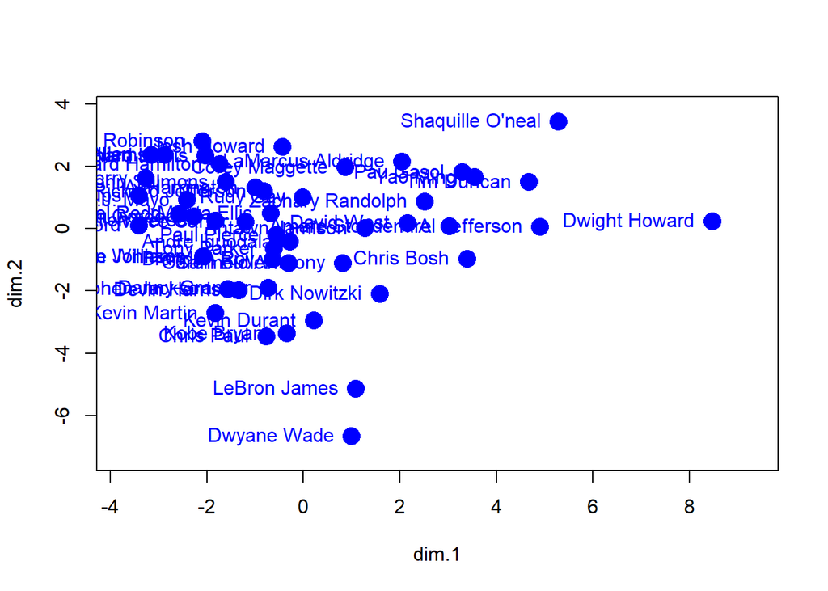

```r
plot(nba.mds$points[,c(1,2)],
     xlim = range(nba.mds$points[,1])*1.1,
     ylim = range(nba.mds$points[,2])*1.1,
     xlab="dim.1",
     ylab="dim.2",
     col= "blue",
     pch= 16,
     cex= 2,
     )

text(nba.mds$points[,c(1,2)], rownames(nba2),
     pos=2, cex=1, col= "blue")
```

This doesn’t seem as clear to me as PCA does with how it separates my values, but it’s clear to me that there are outliers such as Shaquille, Dwight Howard, Lebron and Dwayne Wade that I may need to remove if I were to build a predictive model

Dimension 2 holds predictive properties for a large amount of the data, according to this visual

# Task 2:

### The “Adult2.csv” dataset contains information about 100 key consumers of a sales team. Most of the variables are categorical and then you please use non-metric MDS to demonstrate how this group of consumers are distributed on a map. Discuss your observations and implications.

```r
adults <- read.csv("C:/Users/bae96639/Desktop/Uploads/Adult2.csv")
adults2 <- data.frame(lapply(adults, function(x) ordered(rank(x))))

head(adults2)
```

```
##    age workclass education marital_status occupation race  sex
## 1 53.5      94.5        33           85.5          5   60 63.5
## 2 83.5      88.5        33             44       23.5   60 63.5
## 3 51.5      47.5        60              8       35.5   60 63.5
## 4   89      47.5         4             44       35.5   12 63.5
## 5   20      47.5        33             44       64.5   12 13.5
## 6 48.5      47.5        77             44       23.5   60 13.5
##   work_hours_per_week income
## 1                45.5     63
## 2                   2     63
## 3                45.5     63
## 4                45.5     63
## 5                45.5     63
## 6                45.5     63
```

```r
library(cluster)
library(MASS)
adults.dist <- daisy(adults2, metric="gower")
adults.mds <- isoMDS(adults.dist)
```

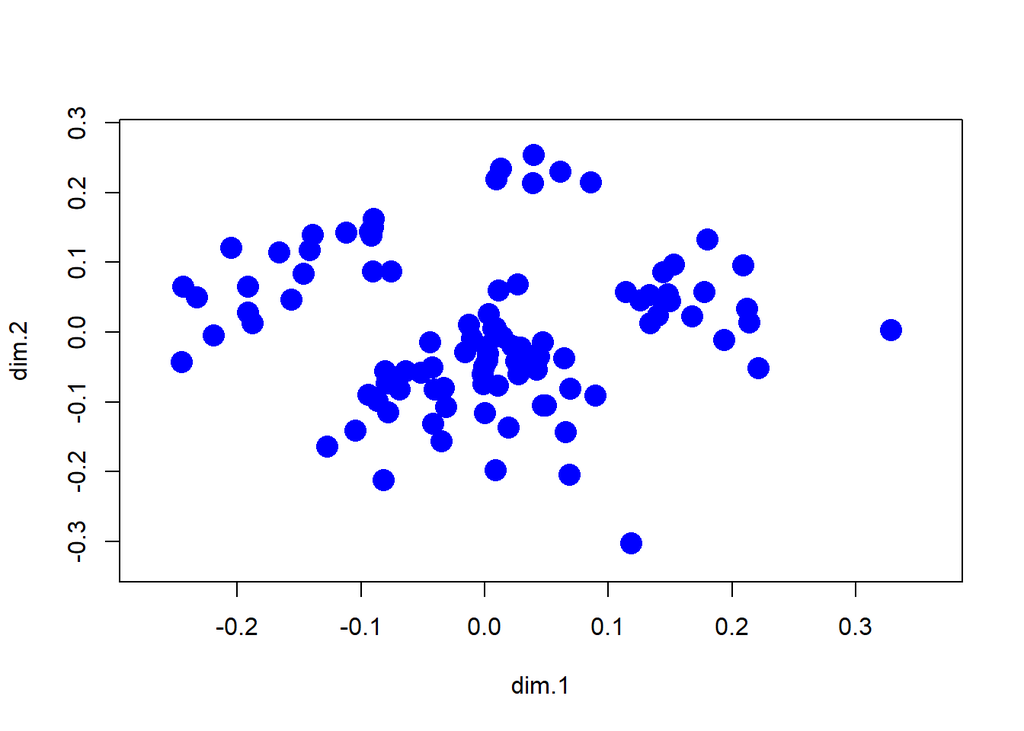

```r
plot(adults.mds$points[,c(1,2)],
     xlim = range(adults.mds$points[,1])*1.1,
     ylim = range(adults.mds$points[,2])*1.1,
     xlab="dim.1",
     ylab="dim.2",
     col= "blue",
     pch= 16,
     cex= 2,
     ) #'text' line from practice removed since it wasn't relevant here
```

Between the two dimensions explored here, it’s apparent that there are four groups in the data: - far right and the upper center don’t seem to correlate as strongly with dimension 1 or 2 when it concerns predictive properties - bottom slightly left seems to lie closer to dimension 1 holding predictive properties, and far left for dimension 2 - one outlier to the furthest right is evident

#Task 3:

### Find a dataset of your own choice (should be related to business/marketing), and you run either a metric or non-metric MDS (depending on the nature of the data) and show how you get and interpret the results. In your answers, please also show the basic structure of your dataset and the basic descriptive information of the variables (along with your analysis, results, and brief interpretations). This task will give everyone a chance to establish your own examples and we can collectively contribute to our class with a broader scope of data analytics applications, which will surely benefit all the students in this class.

```r
avocado <- read.csv("C:/Users/bae96639/Desktop/Uploads/avocado.csv", header = TRUE, sep=",")
head(avocado)
```

```
##   X       Date AveragePrice Total.Volume   X4046     X4225  X4770 Total.Bags
## 1 0 2015-12-27         1.33     64236.62 1036.74  54454.85  48.16    8696.87
## 2 1 2015-12-20         1.35     54876.98  674.28  44638.81  58.33    9505.56
## 3 2 2015-12-13         0.93    118220.22  794.70 109149.67 130.50    8145.35
## 4 3 2015-12-06         1.08     78992.15 1132.00  71976.41  72.58    5811.16
## 5 4 2015-11-29         1.28     51039.60  941.48  43838.39  75.78    6183.95
## 6 5 2015-11-22         1.26     55979.78 1184.27  48067.99  43.61    6683.91
##   Small.Bags Large.Bags XLarge.Bags         type year region
## 1    8603.62      93.25           0 conventional 2015 Albany
## 2    9408.07      97.49           0 conventional 2015 Albany
## 3    8042.21     103.14           0 conventional 2015 Albany
## 4    5677.40     133.76           0 conventional 2015 Albany
## 5    5986.26     197.69           0 conventional 2015 Albany
## 6    6556.47     127.44           0 conventional 2015 Albany
```

```r
#check for NA values
sum(is.na(avocado))
```

```
## [1] 0
```

```r
avocado$X <- NULL #wouldn't let me use the rownames function twice in one rmd
head(avocado)
```

```
##         Date AveragePrice Total.Volume   X4046     X4225  X4770 Total.Bags
## 1 2015-12-27         1.33     64236.62 1036.74  54454.85  48.16    8696.87
## 2 2015-12-20         1.35     54876.98  674.28  44638.81  58.33    9505.56
## 3 2015-12-13         0.93    118220.22  794.70 109149.67 130.50    8145.35
## 4 2015-12-06         1.08     78992.15 1132.00  71976.41  72.58    5811.16
## 5 2015-11-29         1.28     51039.60  941.48  43838.39  75.78    6183.95
## 6 2015-11-22         1.26     55979.78 1184.27  48067.99  43.61    6683.91
##   Small.Bags Large.Bags XLarge.Bags         type year region
## 1    8603.62      93.25           0 conventional 2015 Albany
## 2    9408.07      97.49           0 conventional 2015 Albany
## 3    8042.21     103.14           0 conventional 2015 Albany
## 4    5677.40     133.76           0 conventional 2015 Albany
## 5    5986.26     197.69           0 conventional 2015 Albany
## 6    6556.47     127.44           0 conventional 2015 Albany
```

- Values
- Date - The date of the observation
- AveragePrice - the average price of a single avocado type - conventional or organic
- Year - the year
- Region - the city or region of the observation
- Total Volume - Total number of avocados sold
- 4046 - Total number of avocados with PLU 4046 sold
- 4225 - Total number of avocados with PLU 4225 sold
- 4770 - Total number of avocados with PLU 4770 sold

```r
summary(avocado)
```

```
##          Date        AveragePrice    Total.Volume          X4046
##  2015-01-04:  108   Min.   :0.440   Min.   :      85   Min.   :       0
##  2015-01-11:  108   1st Qu.:1.100   1st Qu.:   10839   1st Qu.:     854
##  2015-01-18:  108   Median :1.370   Median :  107377   Median :    8645
##  2015-01-25:  108   Mean   :1.406   Mean   :  850644   Mean   :  293008
##  2015-02-01:  108   3rd Qu.:1.660   3rd Qu.:  432962   3rd Qu.:  111020
##  2015-02-08:  108   Max.   :3.250   Max.   :62505647   Max.   :22743616
##  (Other)   :17601
##      X4225              X4770           Total.Bags         Small.Bags
##  Min.   :       0   Min.   :      0   Min.   :       0   Min.   :       0
##  1st Qu.:    3009   1st Qu.:      0   1st Qu.:    5089   1st Qu.:    2849
##  Median :   29061   Median :    185   Median :   39744   Median :   26363
##  Mean   :  295155   Mean   :  22840   Mean   :  239639   Mean   :  182195
##  3rd Qu.:  150207   3rd Qu.:   6243   3rd Qu.:  110783   3rd Qu.:   83338
##  Max.   :20470573   Max.   :2546439   Max.   :19373134   Max.   :13384587
##
##    Large.Bags       XLarge.Bags                 type           year
##  Min.   :      0   Min.   :     0.0   conventional:9126   Min.   :2015
##  1st Qu.:    127   1st Qu.:     0.0   organic     :9123   1st Qu.:2015
##  Median :   2648   Median :     0.0                       Median :2016
##  Mean   :  54338   Mean   :  3106.4                       Mean   :2016
##  3rd Qu.:  22029   3rd Qu.:   132.5                       3rd Qu.:2017
##  Max.   :5719097   Max.   :551693.7                       Max.   :2018
##
##                  region
##  Albany             :  338
##  Atlanta            :  338
##  BaltimoreWashington:  338
##  Boise              :  338
##  Boston             :  338
##  BuffaloRochester   :  338
##  (Other)            :16221
```

```r
str(avocado)
```

```
## 'data.frame':    18249 obs. of  13 variables:
##  $ Date        : Factor w/ 169 levels "2015-01-04","2015-01-11",..: 52 51 50 49 48 47 46 45 44 43 ...
##  $ AveragePrice: num  1.33 1.35 0.93 1.08 1.28 1.26 0.99 0.98 1.02 1.07 ...
##  $ Total.Volume: num  64237 54877 118220 78992 51040 ...
##  $ X4046       : num  1037 674 795 1132 941 ...
##  $ X4225       : num  54455 44639 109150 71976 43838 ...
##  $ X4770       : num  48.2 58.3 130.5 72.6 75.8 ...
##  $ Total.Bags  : num  8697 9506 8145 5811 6184 ...
##  $ Small.Bags  : num  8604 9408 8042 5677 5986 ...
##  $ Large.Bags  : num  93.2 97.5 103.1 133.8 197.7 ...
##  $ XLarge.Bags : num  0 0 0 0 0 0 0 0 0 0 ...
##  $ type        : Factor w/ 2 levels "conventional",..: 1 1 1 1 1 1 1 1 1 1 ...
##  $ year        : int  2015 2015 2015 2015 2015 2015 2015 2015 2015 2015 ...
##  $ region      : Factor w/ 54 levels "Albany","Atlanta",..: 1 1 1 1 1 1 1 1 1 1 ...
```

This data set has a lot more observations than what I was previously working with in the first two tasks (18,249)

I want to find a way to define my value names on the plots by the region names

I will remove Date for now since I won’t be doing anything with time series for the purpose of this task

‘type’ will need to be dummied

```r
avocado$Date <- NULL

avocado$type <- ifelse(avocado$type == "conventional",0,1)
avocado$year <- as.numeric(avocado$year)

head(avocado)
```

```
##   AveragePrice Total.Volume   X4046     X4225  X4770 Total.Bags Small.Bags
## 1         1.33     64236.62 1036.74  54454.85  48.16    8696.87    8603.62
## 2         1.35     54876.98  674.28  44638.81  58.33    9505.56    9408.07
## 3         0.93    118220.22  794.70 109149.67 130.50    8145.35    8042.21
## 4         1.08     78992.15 1132.00  71976.41  72.58    5811.16    5677.40
## 5         1.28     51039.60  941.48  43838.39  75.78    6183.95    5986.26
## 6         1.26     55979.78 1184.27  48067.99  43.61    6683.91    6556.47
##   Large.Bags XLarge.Bags type year region
## 1      93.25           0    0 2015 Albany
## 2      97.49           0    0 2015 Albany
## 3     103.14           0    0 2015 Albany
## 4     133.76           0    0 2015 Albany
## 5     197.69           0    0 2015 Albany
## 6     127.44           0    0 2015 Albany
```

```r
str(avocado)
```

```
## 'data.frame':    18249 obs. of  12 variables:
##  $ AveragePrice: num  1.33 1.35 0.93 1.08 1.28 1.26 0.99 0.98 1.02 1.07 ...
##  $ Total.Volume: num  64237 54877 118220 78992 51040 ...
##  $ X4046       : num  1037 674 795 1132 941 ...
##  $ X4225       : num  54455 44639 109150 71976 43838 ...
##  $ X4770       : num  48.2 58.3 130.5 72.6 75.8 ...
##  $ Total.Bags  : num  8697 9506 8145 5811 6184 ...
##  $ Small.Bags  : num  8604 9408 8042 5677 5986 ...
##  $ Large.Bags  : num  93.2 97.5 103.1 133.8 197.7 ...
##  $ XLarge.Bags : num  0 0 0 0 0 0 0 0 0 0 ...
##  $ type        : num  0 0 0 0 0 0 0 0 0 0 ...
##  $ year        : num  2015 2015 2015 2015 2015 ...
##  $ region      : Factor w/ 54 levels "Albany","Atlanta",..: 1 1 1 1 1 1 1 1 1 1 ...
```

```r
avocado1 <- avocado[,c(ncol(avocado),1:(ncol(avocado)-1))]
head(avocado1)
```

```
##   region AveragePrice Total.Volume   X4046     X4225  X4770 Total.Bags
## 1 Albany         1.33     64236.62 1036.74  54454.85  48.16    8696.87
## 2 Albany         1.35     54876.98  674.28  44638.81  58.33    9505.56
## 3 Albany         0.93    118220.22  794.70 109149.67 130.50    8145.35
## 4 Albany         1.08     78992.15 1132.00  71976.41  72.58    5811.16
## 5 Albany         1.28     51039.60  941.48  43838.39  75.78    6183.95
## 6 Albany         1.26     55979.78 1184.27  48067.99  43.61    6683.91
##   Small.Bags Large.Bags XLarge.Bags type year
## 1    8603.62      93.25           0    0 2015
## 2    9408.07      97.49           0    0 2015
## 3    8042.21     103.14           0    0 2015
## 4    5677.40     133.76           0    0 2015
## 5    5986.26     197.69           0    0 2015
## 6    6556.47     127.44           0    0 2015
```

The ‘rownames’ function would not work with my region data because there are obviously duplicate values

In the future I would explore a way to combat this to evaluate region data, but for the purpose of this discussion I will table it for another time

```r
avocado$region <- NULL
head(avocado)
```

```
##   AveragePrice Total.Volume   X4046     X4225  X4770 Total.Bags Small.Bags
## 1         1.33     64236.62 1036.74  54454.85  48.16    8696.87    8603.62
## 2         1.35     54876.98  674.28  44638.81  58.33    9505.56    9408.07
## 3         0.93    118220.22  794.70 109149.67 130.50    8145.35    8042.21
## 4         1.08     78992.15 1132.00  71976.41  72.58    5811.16    5677.40
## 5         1.28     51039.60  941.48  43838.39  75.78    6183.95    5986.26
## 6         1.26     55979.78 1184.27  48067.99  43.61    6683.91    6556.47
##   Large.Bags XLarge.Bags type year
## 1      93.25           0    0 2015
## 2      97.49           0    0 2015
## 3     103.14           0    0 2015
## 4     133.76           0    0 2015
## 5     197.69           0    0 2015
## 6     127.44           0    0 2015
```

```r
set.seed(1234)
avocado100 <- avocado[1:100,]
avocado100 <- avocado100[sample(1:nrow(avocado100)), ]
head(avocado100)
```

```
##    AveragePrice Total.Volume     X4046    X4225   X4770 Total.Bags Small.Bags
## 28         1.27    104849.39    804.01 76688.55 5481.18   21875.65   21662.00
## 80         0.99    554763.76 449311.47 30231.78  678.40   74542.11   55484.76
## 22         1.45     75133.10    509.94 62035.06  741.08   11847.02   11768.52
## 9          1.02     99811.42   1022.15 87315.57   85.34   11388.36   11104.53
## 5          1.28     51039.60    941.48 43838.39   75.78    6183.95    5986.26
## 38         1.13     48364.29    864.27 30374.15   21.50   17104.37   16438.49
##    Large.Bags XLarge.Bags type year
## 28     213.65        0.00    0 2015
## 80   19010.81       46.54    0 2015
## 22      78.50        0.00    0 2015
## 9      283.83        0.00    0 2015
## 5      197.69        0.00    0 2015
## 38     665.88        0.00    0 2015
```

```r
#str(avocado100)
```

```r
avocado.scale<-as.data.frame(scale(avocado100))

avocado.dist<-dist(avocado.scale)

avocado.mds <- cmdscale(avocado.dist,k=11, eig = TRUE)
avocado.mds
```

```
## $points
##          [,1]        [,2]         [,3]         [,4]         [,5]          [,6]
## 28  -1.870474  4.34992111  0.602066931 -1.314723028 -1.378391511  0.4007011974
## 80   4.216846  0.21760607 -0.430478771  0.785161261  0.120359751 -0.9235776245
## 22  -2.981533  1.12157190 -0.991968075 -0.544343457  1.582400654  0.6810098077
## 9   -2.177161 -0.72211653  1.554241272  0.483880627 -0.342432963 -0.5423857356
## 5   -2.795775 -0.29449873 -0.983328000 -0.059757312  0.460489045  0.5908059144
## 38  -1.813516 -0.79028509 -0.881665692  0.085236445 -0.324394903 -0.2446417035
## 16  -2.761243  0.01650814 -0.211063783 -0.052600534  0.834527064  0.3561658522
## 4   -2.510411 -0.77167277  0.792826860  0.394757271 -0.348714580 -0.0289550762
## 86   2.053692 -0.15201190 -1.045633844 -1.029163611 -0.437559985  0.0618048062
## 90   2.348417 -1.37385078 -0.119260036 -0.586109933 -0.452815236  0.6829556912
## 70   2.066662  0.97012231 -0.435512706  0.207080105  0.756252885 -0.6378122661
## 79   3.439279  1.99875229 -1.349529342  4.225267800  0.919053155 -0.4995611694
## 78   3.602721  0.28661873  0.542570208 -0.021405055  0.375780595 -0.7877837911
```

[output cut: 219 more lines]

I chose a metric approach since I’m working with largely numeric data that isn’t ranked

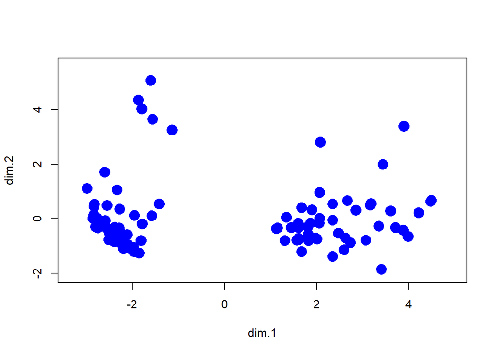

```r
plot(avocado.mds$points[,c(1,2)],
     xlim = range(avocado.mds$points[,1])*1.1,
     ylim = range(avocado.mds$points[,2])*1.1,
     xlab="dim.1",
     ylab="dim.2",
     col= "blue",
     pch= 16,
     cex= 2,
     )
```

MDS has allowed me to sort this sample of my data into two, maybe even three clear clusters

One large cluster falls closer to dimension 1 holding the most predictive properties The second large cluster shows dimensions 1 and 2 holding predictive properties, thought some of the data doesn’t fall as in line with dimension 1 The third small cluster in the top left has some predictive properties within dimension 2, but not as strong as an association as the second cluster Some outliers are visible in the right/center of the graph

This data could be explored further to anticipate pricing, show trends in price, evaluate marketing strategies of avocado type, as well as analyze shortfalls or peaks in volume sold, though the possibilities would not end there

I would be interested in performing PCA on this data and then trying time series analysis with a focus on price and region